# COVID-19 Dataset: Extracting Key Pandemic Insights

J. Valencia

2025-02-25

## Objective

The COVID-19 pandemic has profoundly impacted various aspects of daily life, altering social dynamics, work environments, and interpersonal interactions. This project aims to derive meaningful insights from the Johns Hopkins COVID-19 dataset, with the following objectives:

- Analyze the distribution of COVID-19 cases across countries.
- Examine the distribution of COVID-19-related deaths across countries.
- Identify additional patterns and insights through data analysis.

## Process

### Import data

The data was sourced from https://github.com/CSSEGISandData/COVID-19 and is publicly accessible and free to use.

*An interactive web-based dashboard to track COVID-19 in real time* Dong, Ensheng et al. The Lancet Infectious Diseases, Volume 20, Issue 5, 533 - 534

```r
url <- "https://raw.githubusercontent.com/CSSEGISandData/COVID-19/master/csse_covid_19_data/csse_covid_19_time_series/time_series_covid19_"
file_names <- c("confirmed", "deaths", "recovered")
global_data <- "_global.csv"
urls <- str_c(url, file_names, global_data)

covid19_confirmed <- read_csv(urls[1])
covid19_deaths <- read_csv(urls[2])
covid19_recovered <- read_csv(urls[3])
```

### Be aware of you data.

After importing the data, it is essential to examine the data types to ensure appropriate initial transformations.

```r
covid19_confirmed
```

```
## # A tibble: 289 × 1,147
##    `Province/State`  `Country/Region`   Lat   Long `1/22/20` `1/23/20` `1/24/20`
##    <chr>             <chr>            <dbl>  <dbl>     <dbl>     <dbl>     <dbl>
##  1 <NA>              Afghanistan       33.9  67.7          0         0         0
##  2 <NA>              Albania           41.2  20.2          0         0         0
##  3 <NA>              Algeria           28.0   1.66         0         0         0
##  4 <NA>              Andorra           42.5   1.52         0         0         0
##  5 <NA>              Angola           -11.2  17.9          0         0         0
##  6 <NA>              Antarctica       -71.9  23.3          0         0         0
##  7 <NA>              Antigua and Bar…  17.1 -61.8          0         0         0
##  8 <NA>              Argentina        -38.4 -63.6          0         0         0
##  9 <NA>              Armenia           40.1  45.0          0         0         0
## 10 Australian Capit… Australia        -35.5 149.           0         0         0
## # ℹ 279 more rows
## # ℹ 1,140 more variables: `1/25/20` <dbl>, `1/26/20` <dbl>, `1/27/20` <dbl>,
## #   `1/28/20` <dbl>, `1/29/20` <dbl>, `1/30/20` <dbl>, `1/31/20` <dbl>,
## #   `2/1/20` <dbl>, `2/2/20` <dbl>, `2/3/20` <dbl>, `2/4/20` <dbl>,
## #   `2/5/20` <dbl>, `2/6/20` <dbl>, `2/7/20` <dbl>, `2/8/20` <dbl>,
## #   `2/9/20` <dbl>, `2/10/20` <dbl>, `2/11/20` <dbl>, `2/12/20` <dbl>,
## #   `2/13/20` <dbl>, `2/14/20` <dbl>, `2/15/20` <dbl>, `2/16/20` <dbl>, …
```

```r
covid19_deaths
```

```
## # A tibble: 289 × 1,147
##    `Province/State`  `Country/Region`   Lat   Long `1/22/20` `1/23/20` `1/24/20`
##    <chr>             <chr>            <dbl>  <dbl>     <dbl>     <dbl>     <dbl>
##  1 <NA>              Afghanistan       33.9  67.7          0         0         0
##  2 <NA>              Albania           41.2  20.2          0         0         0
##  3 <NA>              Algeria           28.0   1.66         0         0         0
##  4 <NA>              Andorra           42.5   1.52         0         0         0
##  5 <NA>              Angola           -11.2  17.9          0         0         0
##  6 <NA>              Antarctica       -71.9  23.3          0         0         0
##  7 <NA>              Antigua and Bar…  17.1 -61.8          0         0         0
##  8 <NA>              Argentina        -38.4 -63.6          0         0         0
##  9 <NA>              Armenia           40.1  45.0          0         0         0
## 10 Australian Capit… Australia        -35.5 149.           0         0         0
## # ℹ 279 more rows
## # ℹ 1,140 more variables: `1/25/20` <dbl>, `1/26/20` <dbl>, `1/27/20` <dbl>,
## #   `1/28/20` <dbl>, `1/29/20` <dbl>, `1/30/20` <dbl>, `1/31/20` <dbl>,
## #   `2/1/20` <dbl>, `2/2/20` <dbl>, `2/3/20` <dbl>, `2/4/20` <dbl>,
## #   `2/5/20` <dbl>, `2/6/20` <dbl>, `2/7/20` <dbl>, `2/8/20` <dbl>,
## #   `2/9/20` <dbl>, `2/10/20` <dbl>, `2/11/20` <dbl>, `2/12/20` <dbl>,
## #   `2/13/20` <dbl>, `2/14/20` <dbl>, `2/15/20` <dbl>, `2/16/20` <dbl>, …
```

```r
covid19_recovered
```

```
## # A tibble: 274 × 1,147
##    `Province/State`  `Country/Region`   Lat   Long `1/22/20` `1/23/20` `1/24/20`
##    <chr>             <chr>            <dbl>  <dbl>     <dbl>     <dbl>     <dbl>
##  1 <NA>              Afghanistan       33.9  67.7          0         0         0
##  2 <NA>              Albania           41.2  20.2          0         0         0
##  3 <NA>              Algeria           28.0   1.66         0         0         0
##  4 <NA>              Andorra           42.5   1.52         0         0         0
##  5 <NA>              Angola           -11.2  17.9          0         0         0
##  6 <NA>              Antarctica       -71.9  23.3          0         0         0
##  7 <NA>              Antigua and Bar…  17.1 -61.8          0         0         0
##  8 <NA>              Argentina        -38.4 -63.6          0         0         0
##  9 <NA>              Armenia           40.1  45.0          0         0         0
## 10 Australian Capit… Australia        -35.5 149.           0         0         0
## # ℹ 264 more rows
## # ℹ 1,140 more variables: `1/25/20` <dbl>, `1/26/20` <dbl>, `1/27/20` <dbl>,
## #   `1/28/20` <dbl>, `1/29/20` <dbl>, `1/30/20` <dbl>, `1/31/20` <dbl>,
## #   `2/1/20` <dbl>, `2/2/20` <dbl>, `2/3/20` <dbl>, `2/4/20` <dbl>,
## #   `2/5/20` <dbl>, `2/6/20` <dbl>, `2/7/20` <dbl>, `2/8/20` <dbl>,
## #   `2/9/20` <dbl>, `2/10/20` <dbl>, `2/11/20` <dbl>, `2/12/20` <dbl>,
## #   `2/13/20` <dbl>, `2/14/20` <dbl>, `2/15/20` <dbl>, `2/16/20` <dbl>, …
```

```r
cols_to_delete = c('Province/State', 'Lat', 'Long')

covid19_confirmed <- covid19_confirmed %>% select(-all_of(cols_to_delete))
covid19_deaths <- covid19_deaths %>% select(-all_of(cols_to_delete))
covid19_recovered <- covid19_recovered %>% select(-all_of(cols_to_delete))

covid19_confirmed
```

```
## # A tibble: 289 × 1,144
##    `Country/Region`  `1/22/20` `1/23/20` `1/24/20` `1/25/20` `1/26/20` `1/27/20`
##    <chr>                 <dbl>     <dbl>     <dbl>     <dbl>     <dbl>     <dbl>
##  1 Afghanistan               0         0         0         0         0         0
##  2 Albania                   0         0         0         0         0         0
##  3 Algeria                   0         0         0         0         0         0
##  4 Andorra                   0         0         0         0         0         0
##  5 Angola                    0         0         0         0         0         0
##  6 Antarctica                0         0         0         0         0         0
##  7 Antigua and Barb…         0         0         0         0         0         0
##  8 Argentina                 0         0         0         0         0         0
##  9 Armenia                   0         0         0         0         0         0
## 10 Australia                 0         0         0         0         0         0
## # ℹ 279 more rows
## # ℹ 1,137 more variables: `1/28/20` <dbl>, `1/29/20` <dbl>, `1/30/20` <dbl>,
## #   `1/31/20` <dbl>, `2/1/20` <dbl>, `2/2/20` <dbl>, `2/3/20` <dbl>,
## #   `2/4/20` <dbl>, `2/5/20` <dbl>, `2/6/20` <dbl>, `2/7/20` <dbl>,
## #   `2/8/20` <dbl>, `2/9/20` <dbl>, `2/10/20` <dbl>, `2/11/20` <dbl>,
## #   `2/12/20` <dbl>, `2/13/20` <dbl>, `2/14/20` <dbl>, `2/15/20` <dbl>,
## #   `2/16/20` <dbl>, `2/17/20` <dbl>, `2/18/20` <dbl>, `2/19/20` <dbl>, …
```

```r
covid19_deaths
```

```
## # A tibble: 289 × 1,144
##    `Country/Region`  `1/22/20` `1/23/20` `1/24/20` `1/25/20` `1/26/20` `1/27/20`
##    <chr>                 <dbl>     <dbl>     <dbl>     <dbl>     <dbl>     <dbl>
##  1 Afghanistan               0         0         0         0         0         0
##  2 Albania                   0         0         0         0         0         0
##  3 Algeria                   0         0         0         0         0         0
##  4 Andorra                   0         0         0         0         0         0
##  5 Angola                    0         0         0         0         0         0
##  6 Antarctica                0         0         0         0         0         0
##  7 Antigua and Barb…         0         0         0         0         0         0
##  8 Argentina                 0         0         0         0         0         0
##  9 Armenia                   0         0         0         0         0         0
## 10 Australia                 0         0         0         0         0         0
## # ℹ 279 more rows
## # ℹ 1,137 more variables: `1/28/20` <dbl>, `1/29/20` <dbl>, `1/30/20` <dbl>,
## #   `1/31/20` <dbl>, `2/1/20` <dbl>, `2/2/20` <dbl>, `2/3/20` <dbl>,
## #   `2/4/20` <dbl>, `2/5/20` <dbl>, `2/6/20` <dbl>, `2/7/20` <dbl>,
## #   `2/8/20` <dbl>, `2/9/20` <dbl>, `2/10/20` <dbl>, `2/11/20` <dbl>,
## #   `2/12/20` <dbl>, `2/13/20` <dbl>, `2/14/20` <dbl>, `2/15/20` <dbl>,
## #   `2/16/20` <dbl>, `2/17/20` <dbl>, `2/18/20` <dbl>, `2/19/20` <dbl>, …
```

```r
covid19_recovered
```

```
## # A tibble: 274 × 1,144
##    `Country/Region`  `1/22/20` `1/23/20` `1/24/20` `1/25/20` `1/26/20` `1/27/20`
##    <chr>                 <dbl>     <dbl>     <dbl>     <dbl>     <dbl>     <dbl>
##  1 Afghanistan               0         0         0         0         0         0
##  2 Albania                   0         0         0         0         0         0
##  3 Algeria                   0         0         0         0         0         0
##  4 Andorra                   0         0         0         0         0         0
##  5 Angola                    0         0         0         0         0         0
##  6 Antarctica                0         0         0         0         0         0
##  7 Antigua and Barb…         0         0         0         0         0         0
##  8 Argentina                 0         0         0         0         0         0
##  9 Armenia                   0         0         0         0         0         0
## 10 Australia                 0         0         0         0         0         0
## # ℹ 264 more rows
## # ℹ 1,137 more variables: `1/28/20` <dbl>, `1/29/20` <dbl>, `1/30/20` <dbl>,
## #   `1/31/20` <dbl>, `2/1/20` <dbl>, `2/2/20` <dbl>, `2/3/20` <dbl>,
## #   `2/4/20` <dbl>, `2/5/20` <dbl>, `2/6/20` <dbl>, `2/7/20` <dbl>,
## #   `2/8/20` <dbl>, `2/9/20` <dbl>, `2/10/20` <dbl>, `2/11/20` <dbl>,
## #   `2/12/20` <dbl>, `2/13/20` <dbl>, `2/14/20` <dbl>, `2/15/20` <dbl>,
## #   `2/16/20` <dbl>, `2/17/20` <dbl>, `2/18/20` <dbl>, `2/19/20` <dbl>, …
```

To improve readability, all date columns will be pivoted

```r
covid19_confirmed <- covid19_confirmed %>%
                        pivot_longer(cols = -c("Country/Region"),
                                     names_to = "Date",
                                     values_to = "Cases_confirmed") %>%
                        rename(Country = `Country/Region`) %>%
                        mutate(Date = mdy(Date))

covid19_deaths <- covid19_deaths %>%
                        pivot_longer(cols = -c("Country/Region"),
                                     names_to = "Date",
                                     values_to = "Cases_deceased")%>%
                        rename(Country = `Country/Region`) %>%
                        mutate(Date = mdy(Date))

covid19_recovered <- covid19_recovered %>%
                        pivot_longer(cols = -c("Country/Region"),
                                     names_to = "Date",
                                     values_to = "Cases_recovered")%>%
                        rename(Country = `Country/Region`) %>%
                        mutate(Date = mdy(Date))

covid19_confirmed
```

```
## # A tibble: 330,327 × 3
##    Country     Date       Cases_confirmed
##    <chr>       <date>               <dbl>
##  1 Afghanistan 2020-01-22               0
##  2 Afghanistan 2020-01-23               0
##  3 Afghanistan 2020-01-24               0
##  4 Afghanistan 2020-01-25               0
##  5 Afghanistan 2020-01-26               0
##  6 Afghanistan 2020-01-27               0
##  7 Afghanistan 2020-01-28               0
##  8 Afghanistan 2020-01-29               0
##  9 Afghanistan 2020-01-30               0
## 10 Afghanistan 2020-01-31               0
## # ℹ 330,317 more rows
```

```r
covid19_deaths
```

```
## # A tibble: 330,327 × 3
##    Country     Date       Cases_deceased
##    <chr>       <date>              <dbl>
##  1 Afghanistan 2020-01-22              0
##  2 Afghanistan 2020-01-23              0
##  3 Afghanistan 2020-01-24              0
##  4 Afghanistan 2020-01-25              0
##  5 Afghanistan 2020-01-26              0
##  6 Afghanistan 2020-01-27              0
##  7 Afghanistan 2020-01-28              0
##  8 Afghanistan 2020-01-29              0
##  9 Afghanistan 2020-01-30              0
## 10 Afghanistan 2020-01-31              0
## # ℹ 330,317 more rows
```

```r
covid19_recovered
```

```
## # A tibble: 313,182 × 3
##    Country     Date       Cases_recovered
##    <chr>       <date>               <dbl>
##  1 Afghanistan 2020-01-22               0
##  2 Afghanistan 2020-01-23               0
##  3 Afghanistan 2020-01-24               0
##  4 Afghanistan 2020-01-25               0
##  5 Afghanistan 2020-01-26               0
##  6 Afghanistan 2020-01-27               0
##  7 Afghanistan 2020-01-28               0
##  8 Afghanistan 2020-01-29               0
##  9 Afghanistan 2020-01-30               0
## 10 Afghanistan 2020-01-31               0
## # ℹ 313,172 more rows
```

Next, we will identify and examine any duplicate rows in the dataset.

```r
duplicates_confirmed <- covid19_confirmed %>%
  count(Country, Date) %>%
  filter(n > 1) %>%
  arrange(Country, Date)

duplicates_deaths <- covid19_deaths %>%
  count(Country, Date) %>%
  filter(n > 1) %>%
  arrange(Country, Date)

duplicates_recovered <- covid19_recovered %>%
  count(Country, Date) %>%
  filter(n > 1) %>%
  arrange(Country, Date)

# Print duplicates
print(duplicates_confirmed)
```

```
## # A tibble: 9,144 × 3
##    Country   Date           n
##    <chr>     <date>     <int>
##  1 Australia 2020-01-22     8
##  2 Australia 2020-01-23     8
##  3 Australia 2020-01-24     8
##  4 Australia 2020-01-25     8
##  5 Australia 2020-01-26     8
##  6 Australia 2020-01-27     8
##  7 Australia 2020-01-28     8
##  8 Australia 2020-01-29     8
##  9 Australia 2020-01-30     8
## 10 Australia 2020-01-31     8
## # ℹ 9,134 more rows
```

```r
print(duplicates_deaths)
```

```
## # A tibble: 9,144 × 3
##    Country   Date           n
##    <chr>     <date>     <int>
##  1 Australia 2020-01-22     8
##  2 Australia 2020-01-23     8
##  3 Australia 2020-01-24     8
##  4 Australia 2020-01-25     8
##  5 Australia 2020-01-26     8
##  6 Australia 2020-01-27     8
##  7 Australia 2020-01-28     8
##  8 Australia 2020-01-29     8
##  9 Australia 2020-01-30     8
## 10 Australia 2020-01-31     8
## # ℹ 9,134 more rows
```

```r
print(duplicates_recovered)
```

```
## # A tibble: 8,001 × 3
##    Country   Date           n
##    <chr>     <date>     <int>
##  1 Australia 2020-01-22     8
##  2 Australia 2020-01-23     8
##  3 Australia 2020-01-24     8
##  4 Australia 2020-01-25     8
##  5 Australia 2020-01-26     8
##  6 Australia 2020-01-27     8
##  7 Australia 2020-01-28     8
##  8 Australia 2020-01-29     8
##  9 Australia 2020-01-30     8
## 10 Australia 2020-01-31     8
## # ℹ 7,991 more rows
```

It appears that some countries have duplicate records for the same date. To better understand this issue, we will examine specific examples of how the data is structured.

```r
all_duplicates_confirmed <- covid19_confirmed %>%
  group_by(Country, Date) %>%
  filter(n() > 1) %>%
  arrange(Country, Date)

all_duplicates_deaths <- covid19_deaths %>%
  group_by(Country, Date) %>%
  filter(n() > 1) %>%
  arrange(Country, Date)

all_duplicates_recovered <- covid19_recovered %>%
  group_by(Country, Date) %>%
  filter(n() > 1) %>%
  arrange(Country, Date)

all_duplicates_confirmed
```

```
## # A tibble: 109,728 × 3
## # Groups:   Country, Date [9,144]
##    Country   Date       Cases_confirmed
##    <chr>     <date>               <dbl>
##  1 Australia 2020-01-22               0
##  2 Australia 2020-01-22               0
##  3 Australia 2020-01-22               0
##  4 Australia 2020-01-22               0
##  5 Australia 2020-01-22               0
##  6 Australia 2020-01-22               0
##  7 Australia 2020-01-22               0
##  8 Australia 2020-01-22               0
##  9 Australia 2020-01-23               0
## 10 Australia 2020-01-23               0
## # ℹ 109,718 more rows
```

```r
all_duplicates_deaths
```

```
## # A tibble: 109,728 × 3
## # Groups:   Country, Date [9,144]
##    Country   Date       Cases_deceased
##    <chr>     <date>              <dbl>
##  1 Australia 2020-01-22              0
##  2 Australia 2020-01-22              0
##  3 Australia 2020-01-22              0
##  4 Australia 2020-01-22              0
##  5 Australia 2020-01-22              0
##  6 Australia 2020-01-22              0
##  7 Australia 2020-01-22              0
##  8 Australia 2020-01-22              0
##  9 Australia 2020-01-23              0
## 10 Australia 2020-01-23              0
## # ℹ 109,718 more rows
```

```r
all_duplicates_recovered
```

```
## # A tibble: 91,440 × 3
## # Groups:   Country, Date [8,001]
##    Country   Date       Cases_recovered
##    <chr>     <date>               <dbl>
##  1 Australia 2020-01-22               0
##  2 Australia 2020-01-22               0
##  3 Australia 2020-01-22               0
##  4 Australia 2020-01-22               0
##  5 Australia 2020-01-22               0
##  6 Australia 2020-01-22               0
##  7 Australia 2020-01-22               0
##  8 Australia 2020-01-22               0
##  9 Australia 2020-01-23               0
## 10 Australia 2020-01-23               0
## # ℹ 91,430 more rows
```

Inspecting again the data earlier in the datasets, the different Provinces generate the duplicates later, so we will group by country and date, and then add the cases up.

```r
covid19_confirmed <- covid19_confirmed %>%
                      group_by(Country, Date) %>%
                      summarize(Cases_confirmed = sum(Cases_confirmed, na.rm = TRUE), .groups = "drop")

covid19_deaths <- covid19_deaths %>%
                      group_by(Country, Date) %>%
                      summarize(Cases_deceased = sum(Cases_deceased, na.rm = TRUE), .groups = "drop")

covid19_recovered <- covid19_recovered %>%
                      group_by(Country, Date) %>%
                      summarize(Cases_recovered = sum(Cases_recovered, na.rm = TRUE), .groups = "drop")

covid19_confirmed
```

```
## # A tibble: 229,743 × 3
##    Country     Date       Cases_confirmed
##    <chr>       <date>               <dbl>
##  1 Afghanistan 2020-01-22               0
##  2 Afghanistan 2020-01-23               0
##  3 Afghanistan 2020-01-24               0
##  4 Afghanistan 2020-01-25               0
##  5 Afghanistan 2020-01-26               0
##  6 Afghanistan 2020-01-27               0
##  7 Afghanistan 2020-01-28               0
##  8 Afghanistan 2020-01-29               0
##  9 Afghanistan 2020-01-30               0
## 10 Afghanistan 2020-01-31               0
## # ℹ 229,733 more rows
```

```r
covid19_deaths
```

```
## # A tibble: 229,743 × 3
##    Country     Date       Cases_deceased
##    <chr>       <date>              <dbl>
##  1 Afghanistan 2020-01-22              0
##  2 Afghanistan 2020-01-23              0
##  3 Afghanistan 2020-01-24              0
##  4 Afghanistan 2020-01-25              0
##  5 Afghanistan 2020-01-26              0
##  6 Afghanistan 2020-01-27              0
##  7 Afghanistan 2020-01-28              0
##  8 Afghanistan 2020-01-29              0
##  9 Afghanistan 2020-01-30              0
## 10 Afghanistan 2020-01-31              0
## # ℹ 229,733 more rows
```

```r
covid19_recovered
```

```
## # A tibble: 229,743 × 3
##    Country     Date       Cases_recovered
##    <chr>       <date>               <dbl>
##  1 Afghanistan 2020-01-22               0
##  2 Afghanistan 2020-01-23               0
##  3 Afghanistan 2020-01-24               0
##  4 Afghanistan 2020-01-25               0
##  5 Afghanistan 2020-01-26               0
##  6 Afghanistan 2020-01-27               0
##  7 Afghanistan 2020-01-28               0
##  8 Afghanistan 2020-01-29               0
##  9 Afghanistan 2020-01-30               0
## 10 Afghanistan 2020-01-31               0
## # ℹ 229,733 more rows
```

To facilitate the analysis, we will merge the three datasets into a single unified dataset.

```r
covid19_dataset <- covid19_confirmed %>%
                  full_join(covid19_deaths) %>%
                  full_join(covid19_recovered) %>%
                  mutate(Country = as.factor(Country))
covid19_dataset
```

```
## # A tibble: 229,743 × 5
##    Country     Date       Cases_confirmed Cases_deceased Cases_recovered
##    <fct>       <date>               <dbl>          <dbl>           <dbl>
##  1 Afghanistan 2020-01-22               0              0               0
##  2 Afghanistan 2020-01-23               0              0               0
##  3 Afghanistan 2020-01-24               0              0               0
##  4 Afghanistan 2020-01-25               0              0               0
##  5 Afghanistan 2020-01-26               0              0               0
##  6 Afghanistan 2020-01-27               0              0               0
##  7 Afghanistan 2020-01-28               0              0               0
##  8 Afghanistan 2020-01-29               0              0               0
##  9 Afghanistan 2020-01-30               0              0               0
## 10 Afghanistan 2020-01-31               0              0               0
## # ℹ 229,733 more rows
```

```r
str(covid19_dataset)
```

```
## tibble [229,743 × 5] (S3: tbl_df/tbl/data.frame)
##  $ Country        : Factor w/ 201 levels "Afghanistan",..: 1 1 1 1 1 1 1 1 1 1 ...
##  $ Date           : Date[1:229743], format: "2020-01-22" "2020-01-23" ...
##  $ Cases_confirmed: num [1:229743] 0 0 0 0 0 0 0 0 0 0 ...
##  $ Cases_deceased : num [1:229743] 0 0 0 0 0 0 0 0 0 0 ...
##  $ Cases_recovered: num [1:229743] 0 0 0 0 0 0 0 0 0 0 ...
```

```r
summary(covid19_dataset)
```

```
##         Country            Date            Cases_confirmed
##  Afghanistan:  1143   Min.   :2020-01-22   Min.   :        0
##  Albania    :  1143   1st Qu.:2020-11-02   1st Qu.:     3831
##  Algeria    :  1143   Median :2021-08-15   Median :    52933
##  Andorra    :  1143   Mean   :2021-08-15   Mean   :  1379412
##  Angola     :  1143   3rd Qu.:2022-05-28   3rd Qu.:   499592
##  Antarctica :  1143   Max.   :2023-03-09   Max.   :103802702
##  (Other)    :222885
##  Cases_deceased    Cases_recovered
##  Min.   :      0   Min.   :      -1
##  1st Qu.:     46   1st Qu.:       0
##  Median :    786   Median :       0
##  Mean   :  19238   Mean   :  102251
##  3rd Qu.:   7227   3rd Qu.:    3722
##  Max.   :1123836   Max.   :30974748
##
```

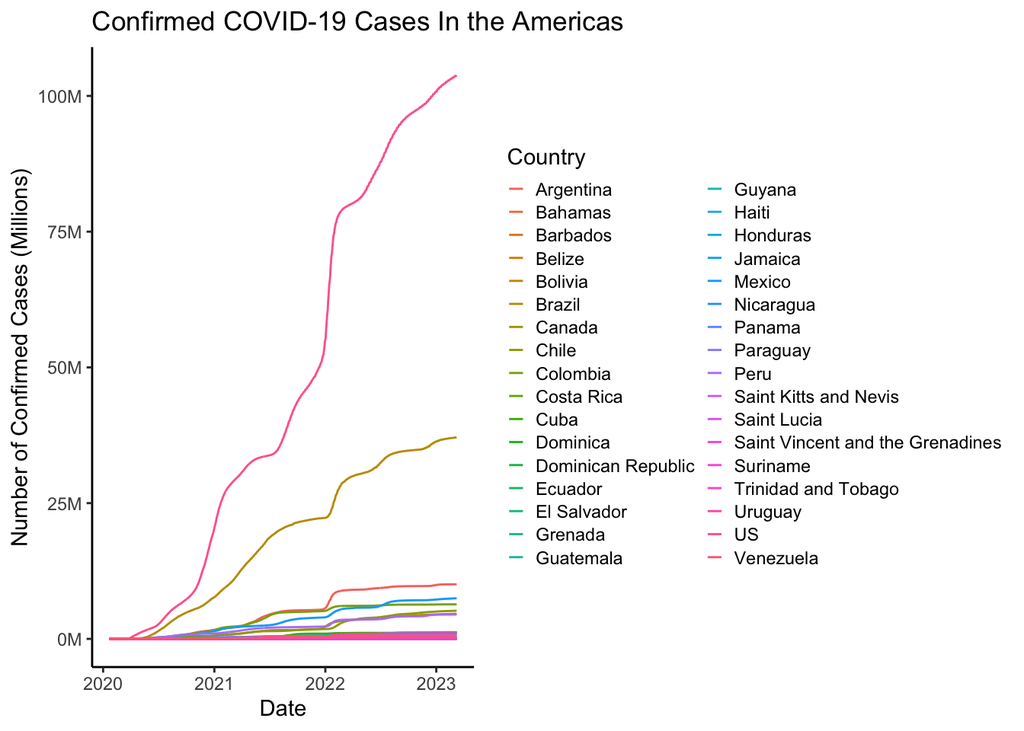

```r
Americas_countries <- c("Argentina", "Bahamas", "Barbados", "Belize", "Bolivia", "Brazil", "Canada", "Chile",
                        "Colombia", "Costa Rica", "Cuba", "Dominica", "Dominican Republic", "Ecuador", "El Salvador",
                        "Grenada", "Guatemala", "Guyana", "Haiti", "Honduras", "Jamaica", "Mexico", "Nicaragua",
                        "Panama", "Paraguay", "Peru", "Saint Kitts and Nevis", "Saint Lucia", "Saint Vincent and the Grenadines",
                        "Suriname", "Trinidad and Tobago", "US", "Uruguay", "Venezuela")

Americas_over_time <- covid19_dataset %>%
                              filter(Country %in% Americas_countries)

plot_cases_over_time = ggplot(Americas_over_time, aes(x = Date, y = Cases_confirmed, color = Country)) +
                              geom_line() +
                              labs(title = "Confirmed COVID-19 Cases In the Americas",
                                   y = "Number of Confirmed Cases (Millions)",
                                   x = "Date") +
                              scale_y_continuous(labels = label_number(scale = 1e-6, suffix = "M")) +
                              theme_classic()+
                              theme(
                                legend.key.size = unit(0.3, "cm"),
                                legend.position = "right",
                                legend.key.height = unit(0.4, "cm"),
                              ) +
                              guides(color = guide_legend(ncol = 2))

plot_cases_over_time
```

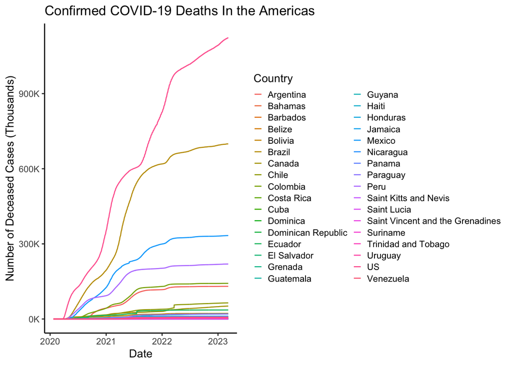

```r
plot_deaths_over_time = ggplot(Americas_over_time, aes(x = Date, y = Cases_deceased, color = Country)) +
                              geom_line() +
                              labs(title = "Confirmed COVID-19 Deaths In the Americas",
                                   y = "Number of Deceased Cases (Thousands)",
                                   x = "Date") +
                              scale_y_continuous(labels = label_number(scale = 1e-3, suffix = "K")) +
                              theme_classic()+
                              theme(
                                legend.key.size = unit(0.3, "cm"),
                                legend.position = "right",
                                legend.key.height = unit(0.4, "cm"),
                              ) +
                              guides(color = guide_legend(ncol = 2))

plot_deaths_over_time
```

```r
deaths_vs_cases = Americas_over_time %>%
                    filter(
                      month(Date) %in% c(3,6,9,12) &
                      day(Date) == days_in_month(Date)
                    )

color_palette <- c(
  "#1f77b4", "#ff7f0e", "#2ca02c", "#d62728", "#9467bd", "#8c564b", "#e377c2", "#7f7f7f",
  "#bcbd22", "#17becf", "#aec7e8", "#ffbb78", "#98df8a", "#ff9896", "#c5b0d5", "#c49c94",
  "#f7b6d2", "#c7c7c7", "#dbdb8d", "#9edae5", "#393b79", "#637939", "#8c6d31", "#843c39",
  "#7b4173", "#5254a3", "#8ca252", "#bd9e39", "#ad494a", "#a55194", "#6b6ecf", "#b5cf6b",
  "#e7ba52", "#d6616b", "#ce6dbd", "#9c9ede"
)

deaths_vs_cases_plot = ggplot(deaths_vs_cases, aes(x = Cases_confirmed, y = Cases_deceased, color = Country)) +
                              geom_point(alpha=0.6) +
                              labs(title = "Correlation Between Confirmed Cases and Deaths",
                                   x = "Confirmed Cases (Millions)",
                                   y = "Deceased Cases (Thousands)",) +
                              scale_x_continuous(labels = scales::label_number(scale = 1e-6, suffix = "M")) +
                              scale_y_continuous(labels = scales::label_number(scale = 1e-3, suffix = "K")) +
                              scale_color_manual(values = color_palette) + #Custom color palette since data exceeds most pallettes availables
                              theme_classic()+
                              theme(
                                legend.key.size = unit(0.3, "cm"),
                                legend.position = "right",
                                legend.key.height = unit(0.4, "cm"),
                              ) +
                              guides(color = guide_legend(ncol = 2))

deaths_vs_cases
```

```
## # A tibble: 408 × 5
##    Country   Date       Cases_confirmed Cases_deceased Cases_recovered
##    <fct>     <date>               <dbl>          <dbl>           <dbl>
##  1 Argentina 2020-03-31            1054             27             240
##  2 Argentina 2020-06-30           64530           1307           22028
##  3 Argentina 2020-09-30          751001          16937          594645
##  4 Argentina 2020-12-31         1625514          43245         1426676
##  5 Argentina 2021-03-31         2348821          55858         2102616
##  6 Argentina 2021-06-30         4470374          94304         4076921
##  7 Argentina 2021-09-30         5256902         115179               0
##  8 Argentina 2021-12-31         5654408         117169               0
##  9 Argentina 2022-03-31         9037911         128019               0
## 10 Argentina 2022-06-30         9367172         129070               0
## # ℹ 398 more rows
```

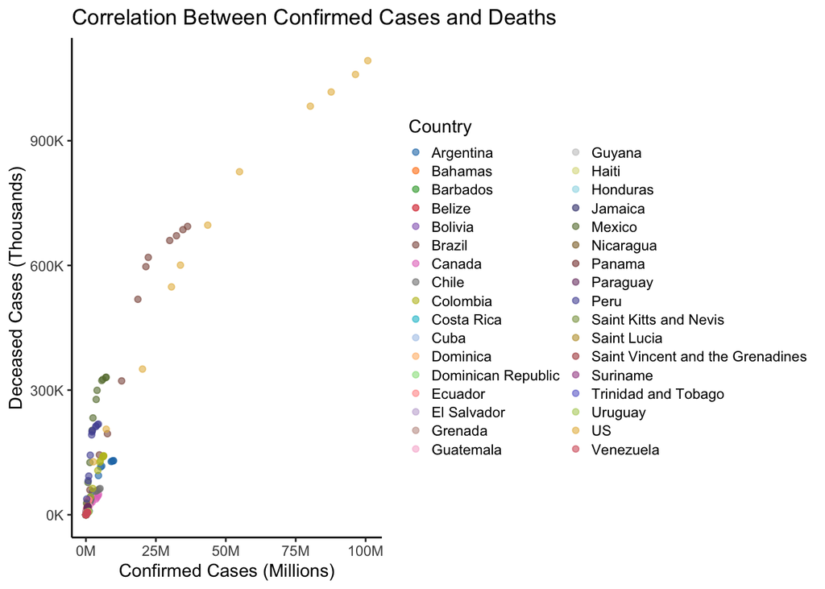

```r
deaths_vs_cases_plot
```

The scatterplot reveals that data points are clustered toward the lower left, exhibiting a right-skewed trend. To address this, we will transform the continuous axis scale to a logarithmic scale. However, since some days have values of zero, this transformation may result in −∞ values on the axis.

```r
deaths_vs_cases_plot = ggplot(deaths_vs_cases, aes(x = Cases_confirmed, y = Cases_deceased, color = Country)) +
                              geom_point(alpha=0.6) +
                              labs(title = "Correlation Between Confirmed Cases and Deaths",
                                   x = "Confirmed Cases (Millions)",
                                   y = "Deceased Cases (Thousands)",) +
                              scale_x_log10(labels = scales::label_number(scale = 1e-6, suffix = "M")) +
                              scale_y_log10(labels = scales::label_number(scale = 1e-3, suffix = "K")) +
                              scale_color_manual(values = color_palette) + #Custom color palette since data exceeds most pallettes availables
                              theme_classic()+
                              theme(
                                legend.key.size = unit(0.3, "cm"),
                                legend.position = "right",
                                legend.key.height = unit(0.4, "cm"),
                              ) +
                              guides(color = guide_legend(ncol = 2))

deaths_vs_cases
```

```
## # A tibble: 408 × 5
##    Country   Date       Cases_confirmed Cases_deceased Cases_recovered
##    <fct>     <date>               <dbl>          <dbl>           <dbl>
##  1 Argentina 2020-03-31            1054             27             240
##  2 Argentina 2020-06-30           64530           1307           22028
##  3 Argentina 2020-09-30          751001          16937          594645
##  4 Argentina 2020-12-31         1625514          43245         1426676
##  5 Argentina 2021-03-31         2348821          55858         2102616
##  6 Argentina 2021-06-30         4470374          94304         4076921
##  7 Argentina 2021-09-30         5256902         115179               0
##  8 Argentina 2021-12-31         5654408         117169               0
##  9 Argentina 2022-03-31         9037911         128019               0
## 10 Argentina 2022-06-30         9367172         129070               0
## # ℹ 398 more rows
```

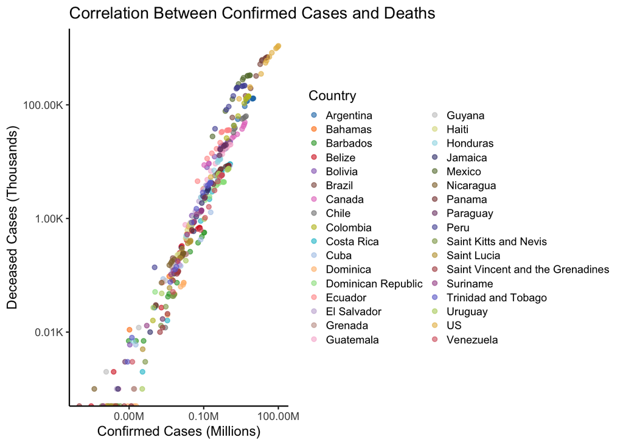

```r
deaths_vs_cases_plot
```

With the logarithmic transformation, the data now exhibits a more linear pattern. Given this correlation, we aim to predict the number of deaths based on features such as location, date, and confirmed cases.

```r
# Exctract some other usefull information foor temporal vairables
Americas_over_time_processed = Americas_over_time %>%
                    mutate(
                      Month = month(Date),
                      Day= day(Date),
                      Days_collected = as.numeric(Date - min(Date))
                    ) %>%
                    select(-Date)

Americas_over_time_processed$Country <- droplevels(Americas_over_time_processed$Country)

#Split the Data
set.seed(40)
train_data_index <- createDataPartition(Americas_over_time_processed$Cases_deceased, p=0.8, list = FALSE)
train_data <- Americas_over_time_processed[train_data_index, ]
test_data <- Americas_over_time_processed[-train_data_index, ]

#Train the model

rf <- randomForest(
  Cases_deceased ~ Country + Cases_confirmed + Month + Day + Days_collected,
  data = train_data,
  ntree = 100,
  importance = TRUE
)

#Evaluate the model
predictions <- predict(rf, test_data)

#Feature importance
importance(rf)
```

```
##                   %IncMSE IncNodePurity
## Country         15.441396  3.082597e+14
## Cases_confirmed 15.506765  3.310382e+14
## Month           10.753176  3.046707e+12
## Day             -4.640481  1.303948e+12
## Days_collected  16.571824  5.056940e+13
```

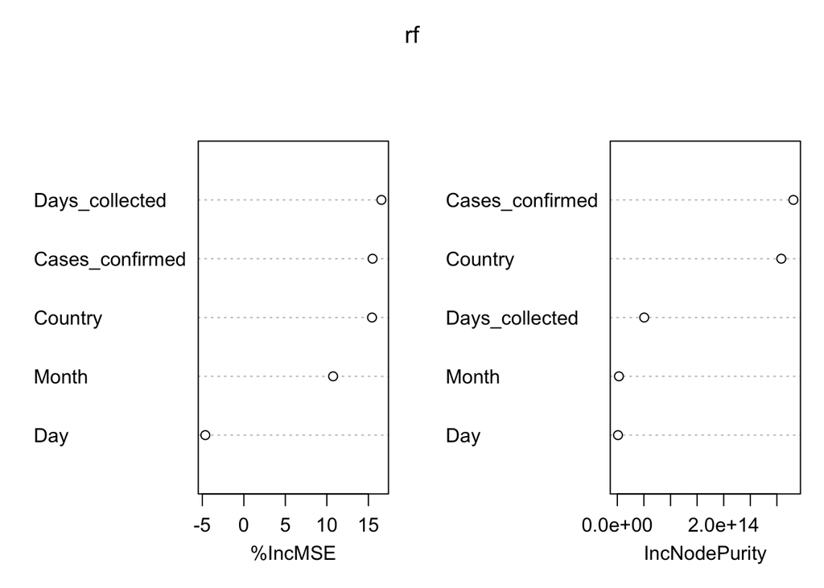

```r
varImpPlot(rf)
```

From this model, we can conclude the following: Days_collected (the number of days since data collection began) is the most significant feature in reducing prediction error. Month has a moderate impact on prediction accuracy. Day does not contribute meaningfully to the model and may introduce noise. Country is a crucial feature for both prediction accuracy and node splitting in the model.

## Conclusions

he Johns Hopkins COVID-19 Datasets provide valuable insights into pandemic dynamics. However, it is essential to recognize potential limitations. For instance, while Days_collected was identified as the most important variable, the dataset lacks explicit information on daily variation, which may introduce bias. A more robust approach would involve analyzing day-to-day variability in terms of daily new cases rather than cumulative cases, allowing for a more precise assessment of trends.